# Data Report on Somerset Levels Project

Daniel Smith

Abundances of four mosquito species larvae aggregated across all sites and plots for the years 2009-2011 and each season that was recorded. Additionally aggregated abundances are proved for all seasons, as well as a grand total of all abundances across seasons. Species *Cs. morsitans*, *Cs. cantans*, *Cs. caspius* have been removed from the analysis because they were virtually absent in all plots. 2010 is the only complete year where samples were taken throughout all seasons.

| Species | Season May | Season Jun/Jul | Season Aug/Sep | Season All Season |
| --- | --- | --- | --- | --- |
| 2009 |  |  |  |  |
| An. claviger | 0 | 45 | 124 | 169 |
| An. maculipennis | 0 | 45 | 13 | 58 |
| Cs. annulata | 0 | 451 | 962 | 1413 |
| Cx. pipiens | 0 | 520 | 485 | 1005 |
| 2010 |  |  |  |  |
| An. claviger | 2 | 55 | 42 | 99 |
| An. maculipennis | 4 | 39 | 37 | 80 |
| Cs. annulata | 35 | 1144 | 1216 | 2395 |
| Cx. pipiens | 33 | 437 | 2620 | 3090 |
| 2011 |  |  |  |  |
| An. claviger | 30 | 0 | 0 | 30 |
| An. maculipennis | 1 | 0 | 0 | 1 |
| Cs. annulata | 21 | 0 | 0 | 21 |
| Cx. pipiens | 27 | 0 | 0 | 27 |
| Total | 153 | 2,736 | 5,499 | 8,388 |

#### Structural characteristics of Tier 1 and Tier 3 management practices compared:

Waterboard level (or freeboard) is consistently lower in tier 3 management in all seasons. This is expected and means the water is never allowed to drop below 0.35m of the land level in guidance with the tier 3 management practice. Average width of rhynes is slightly larger for tier 3 managed plots across all seasons. Depths at both the centre and proximal edges of rhynes are fairly consistent throughout both management tiers, with slight variations in season 1 and 2.

The majority of plots were recorded as pasture for tier 1 sites and rough pasture for tier 3 sites. This shows clearly the reduced grazing pressure and reduced management of rhynes in tier 3 plots as depicted by the scheme guidelines. Differences in exposure are slight, with more exposed sunny sights in Tier 3 managed sites and plots. Differences in shaded structure are seen between the two management sites

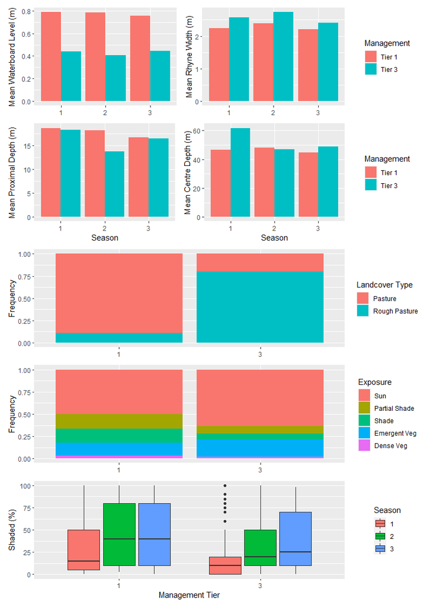

#### Water chemistry characteristics:

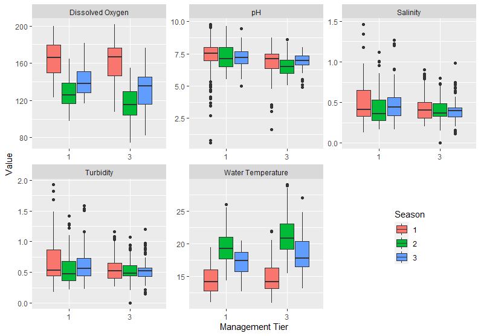

[figure not shown]

Abundance characteristics

[figure not shown]